# Anthracnose on tamarillo selections

Andrea Sotomayor

Peter Alspach

August 2017

## Get the data

```r
setwd("~/GitHub/Ecuador/ExptalData/Andrea")
rm(list=ls()) # clears the global environment
library(readxl)
TaData<- read_excel("TreeTomatoData.xlsx", sheet = "Data", na = 'NA')
TaData$Material <- factor(TaData$Material)

# summary(TaData)
# table(TaData$Material)

TaData$lesArea <- TaData$Decua*TaData$Dlong*pi # lesion area

TaAgg <- aggregate(TaData[,c("Decua","Dlong","lesArea")], TaData[,c("Material","Date","Rep")], mean,
                   na.rm=TRUE)
```

Notes on the code:

- It can be useful to start with a clean global environment. This is achieved by `rm(list=ls())`
- The `aggregate` function is useful for aggregating a number of variates (in this case lesion dimensions) according to some grouping (in this case ‘Material’, ‘Date’ and ‘Rep’; i.e., giving the mean for each tray of 5 fruit).

## Plot lesion areas for controls on time

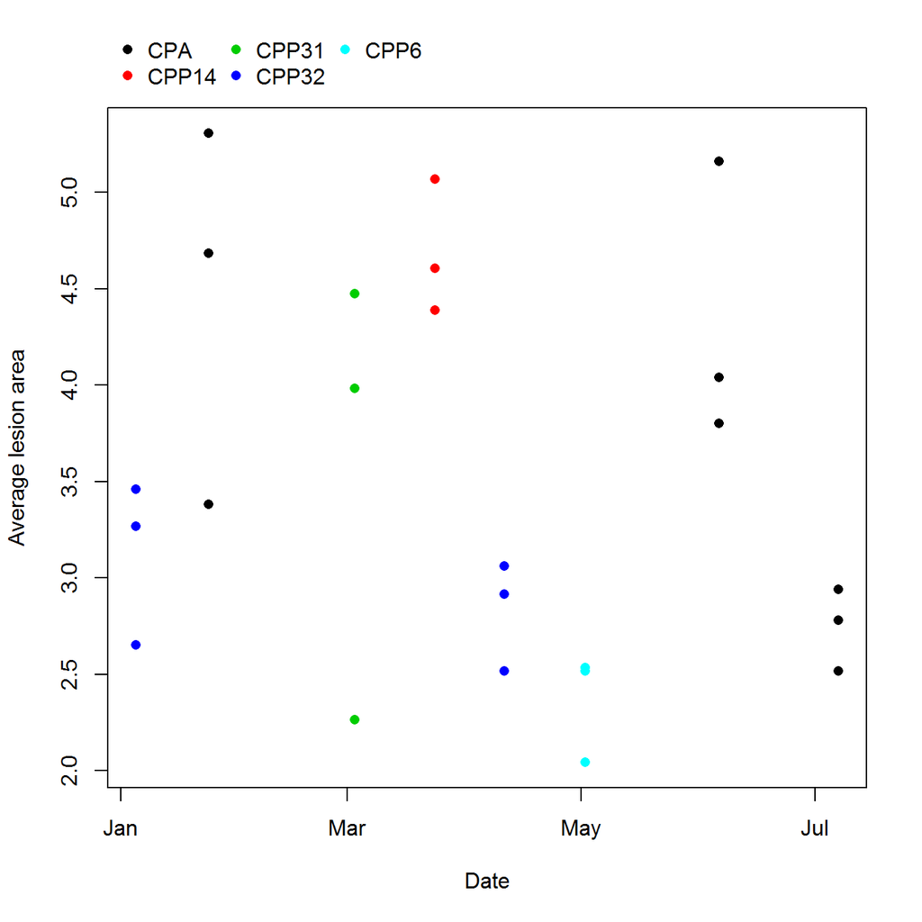

```r
ttCont <- TaAgg[substring(TaAgg$Material, 1, 2)=='CP',]
ttCont$Material <- factor(ttCont$Material)
plot(ttCont$Date, sqrt(ttCont$lesArea), xlab='Date', ylab='Average lesion area', pch=16,
     col=ttCont$Material)
pc <- par()$usr # coordinates of the plot corners
legend(pc[1], pc[4]+diff(pc[3:4])/8, levels(ttCont$Material), col=factor(levels(ttCont$Material)),
       pch=16, ncol=3, bty='n', xpd=TRUE)
```

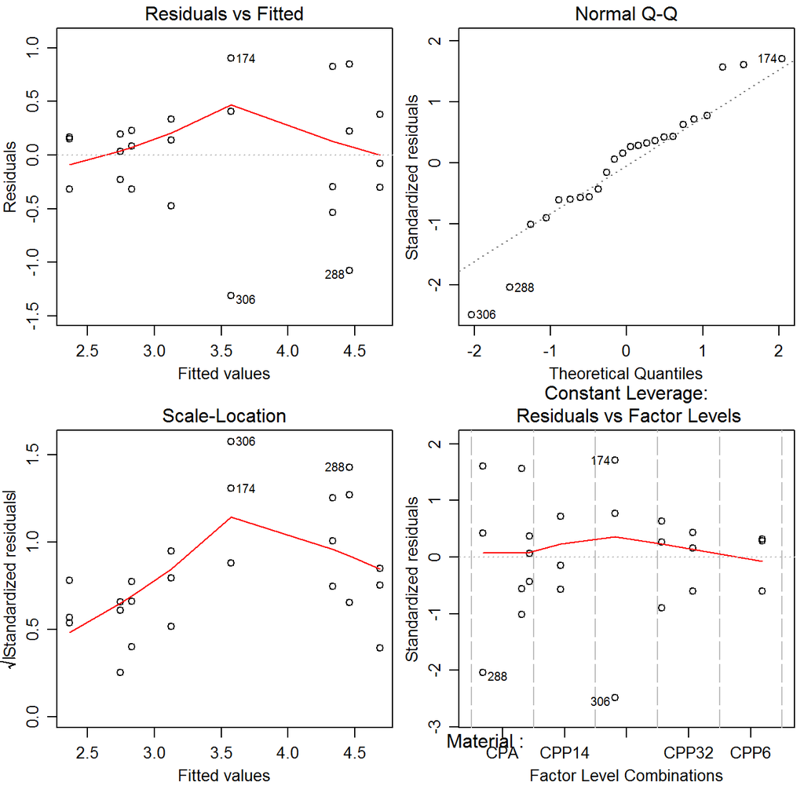

```r
ttAOV <- aov(sqrt(lesArea)~Material+factor(Date), data=ttCont)
par(mfrow=c(2,2), mgp=c(2, 0.8, 0), mar=c(4,3,1.5,0.5))
plot(ttAOV)
```

```r
anova(ttAOV)
```

```
## Analysis of Variance Table
##
## Response: sqrt(lesArea)
##              Df  Sum Sq Mean Sq F value   Pr(>F)
## Material      4 10.8018 2.70046  6.4594 0.002718 **
## factor(Date)  3  5.5957 1.86522  4.4616 0.018505 *
## Residuals    16  6.6890 0.41806
## ---
## Signif. codes:  0 '***' 0.001 '**' 0.01 '*' 0.05 '.' 0.1 ' ' 1
```

Notes on the code:

- We use `substring` to get those values that begin with ‘CP’
- `par` can be used to set graphics parameters (e.g., `par(mfrow=c(2,2))`). It can also be called to get the parameters, which are named. `par()$usr` gives the location of the extremes of the plot in graph units. This is useful to ensure that the legend is located relative to the plot, irrespective on the magnitude of the values. It doesn’t work too well in Rmarkdown as it is also affect by the `fig.height` option
- The graphics parameters `mgp` and `mar` are introdcuted
- The analysis of variance is a quick look to confirm that Date effects are likely to be important. CPA was yellow fruit from the shop, and the CPPnumbers were from different plants of the same purple fleshed cultivar growing at Tumbaco. The question is whether the difference is due to date or plant (perhaps fruit of different maturity).
- Results for CPP32 were similar on both dates
- Care was taken to ensure standard process in all dates. That is, fruit were surface sterilised and kept in a temperature and humidity controlled cabinet

For these reasons we suspect that the differences were due to plants/cultivars/fruit maturity rather than date *per se*. Nevertheless, it is probably prudent to adjust for date (i.e., include Date in the model).

## Examine the selections

The families were planted in blocks and thus we cannot really use field position in any analysis.

Conduct analysis of variance

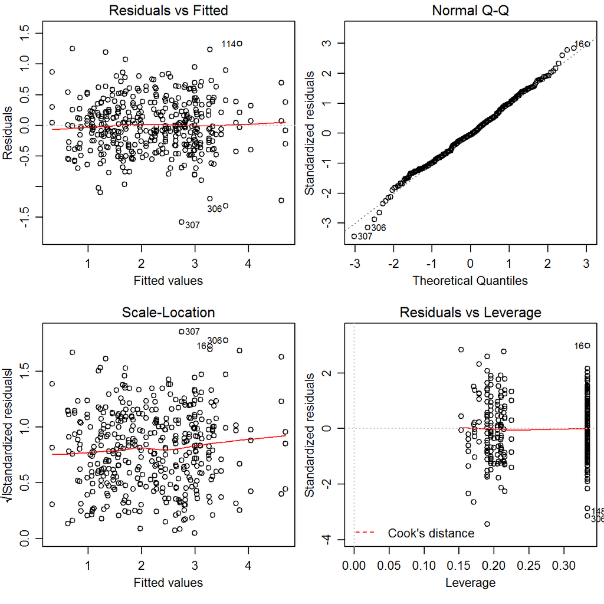

```r
selnAOV <- aov(sqrt(lesArea)~Material+factor(Date), data=TaAgg)
selnAOV1 <- aov(sqrt(lesArea)~factor(Date)+Material, data=TaAgg) # fitting Date first
par(mfrow=c(2,2), mgp=c(2, 0.8, 0), mar=c(4,3,1.5,0.5))
plot(selnAOV)
```

```r
anova(selnAOV)
```

```
## Analysis of Variance Table
##
## Response: sqrt(lesArea)
##               Df  Sum Sq Mean Sq F value    Pr(>F)
## Material     104 263.069  2.5295  9.7223 < 2.2e-16 ***
## factor(Date)   7  42.507  6.0724 23.3395 < 2.2e-16 ***
## Residuals    284  73.890  0.2602
## ---
## Signif. codes:  0 '***' 0.001 '**' 0.01 '*' 0.05 '.' 0.1 ' ' 1
```

However, a mixed model is probably more appropriate

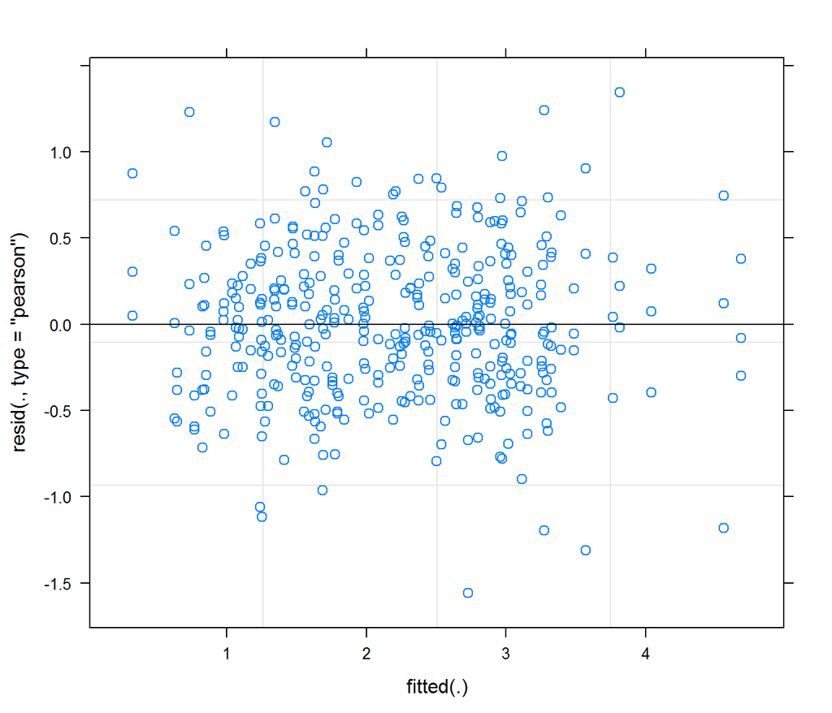

```r
library(lme4)
TaAgg$DateFact <- factor(TaAgg$Date)

selnMM <- lmer(sqrt(lesArea)~-1+Material+(1|DateFact), data=TaAgg)
par(mfrow=c(1,1), mgp=c(2, 0.8, 0), mar=c(4,3,0.5,0.5))
plot(selnMM)
```

```r
anova(selnMM)
```

```
## Analysis of Variance Table
##           Df Sum Sq Mean Sq F value
## Material 105 230.96  2.1997  8.4614
```

```r
ests <- summary(selnMM)$coefficients # get the estimates
(estsOrd <- ests[order(ests[,'Estimate']),])
```

```
##                     Estimate Std. Error     t value
## MaterialGT15P6    0.03875475  0.4064885  0.09534035
## MaterialGT7R1P5   0.27250868  0.4064885  0.67039705
## MaterialGT13P6    0.42906140  0.4064885  1.05553151
## MaterialGT33P7    0.57408469  0.4064885  1.41230249
## MaterialGT33P8    0.81290797  0.3312417  2.45412362
## MaterialGT3P3     0.89156255  0.4064885  2.19332796
## MaterialGT10P10   1.10470592  0.3252474  3.39650931
## MaterialGT10P2    1.13730935  0.3221008  3.53091137
## MaterialGT15P11   1.17759313  0.4064885  2.89699017
## MaterialGT10P7    1.20369181  0.3213097  3.74620432
## MaterialGT10P24   1.22549694  0.3222794  3.80259211
## MaterialGT20P5    1.25250857  0.4946903  2.53190439
## MaterialGT13P2    1.26090778  0.4053428  3.11071979
## MaterialGT7R2P7   1.36130050  0.3260843  4.17468840
## MaterialGT10P8    1.41674186  0.3213097  4.40927189
## MaterialGT13P9    1.43749444  0.4053428  3.54636753
## MaterialGT10P15   1.44002287  0.3931274  3.66299248
## MaterialGT7R1P39  1.48153109  0.4946903  2.99486578
## MaterialGT20P9    1.50609012  0.4946903  3.04451104
## MaterialGT3P9     1.55855556  0.3312417  4.70519189
## MaterialGT3P8     1.56510697  0.3312417  4.72497024
## MaterialGT33P3    1.60544916  0.3312417  4.84676105
## MaterialGT9P3     1.60668683  0.4946903  3.24786395
## MaterialGT13P22   1.62151704  0.3938063  4.11755003
## MaterialGT7R2P11  1.62499713  0.3959365  4.10418577
## MaterialGT10P3    1.64171788  0.3261806  5.03315682
## MaterialGT7R2P3   1.65199569  0.3931274  4.20218868
## MaterialGT10P12   1.68596191  0.3252474  5.18362870
## MaterialGT15P12   1.68659797  0.4064885  4.14919011
## MaterialGT15P1    1.71082249  0.3959365  4.32095121
## MaterialGT10P25   1.73028328  0.3206419  5.39631027
## MaterialGT3P5     1.74936164  0.4064885  4.30359465
## MaterialGT10P9-2  1.79175021  0.3221008  5.56270043
## MaterialGT15P13-2 1.79472295  0.3931274  4.56524464
## MaterialGT13P16   1.80133133  0.3938063  4.57415598
## MaterialGT9P5     1.85473222  0.3931274  4.71789049
## MaterialGT7R2P4   1.87626057  0.3959365  4.73879110
## MaterialGT7R2P6   1.87889384  0.3959365  4.74544185
## MaterialGT10P26   1.88020865  0.3931274  4.78269499
```

[output cut: 51 more lines]

```
## MaterialGT13P18   3.30878552  0.4075570  8.11858300
## MaterialGT9P16    3.38034635  0.4000161  8.45052572
## MaterialGT9P17    3.38345685  0.4000161  8.45830166
## MaterialGT20P8    3.39267969  0.4946903  6.85818907
## MaterialGT7R1P6   3.41250907  0.4946903  6.89827351
## MaterialGT10P1    3.48742002  0.4000161  8.71819911
## MaterialGT9P7     3.52228483  0.4000161  8.80535764
## MaterialGT7R1P19  3.60811454  0.4000161  9.01992326
## MaterialGT9P21    3.62742068  0.4946903  7.33271017
## MaterialCPA       3.74748508  0.2984663 12.55580446
## MaterialGT33P4    3.75129779  0.4000161  9.37786700
## MaterialGT9P10    3.79513665  0.4000161  9.48745972
## MaterialGT9P26    3.82009839  0.4000161  9.54986157
## MaterialCPP14     4.10479006  0.4053428 10.12671336
## MaterialGT33P5    4.53479898  0.4000161 11.33654113
```

Notes on the code:

- The concept of mixed models is a bit complex, and I will not attempt to summarise it in a few sentences. Put simply we model fixed and random effects separately. Random effects are coded in the `lmer` series of functions by putting them in brackets
- The parameterisation is, like `lm`, such that effects are relative to the first level of the first fixed effect. When there is only one factor as a fixed effect, it can be useful to circumvent this by not fitting an intercept (or general mean). This is the purpose of the `-1`in the model formula
- The standar errors of the estimates vary from 0.3 to 0.49, with the lower values generally being the controls which had more replications. The mean standard error is 0.4, and thus the mean standard error of the difference between two estimates is sqrt(2) times this (i.e., 0.57). To get the approximate least significant difference (LSD) at the 5% level this should be multipled by 2
- The best selection (i.e., that with the least value after adjusting for date) is GT15P6 at 0.04. Add the LSD to this value to get those selections which are‘not significantly different’ from this (but remember to use your other knowledge in interpreting this).

## Compare simple, aov and MM means

It might be interesting to compare how the selection means for the different models compare with one another.

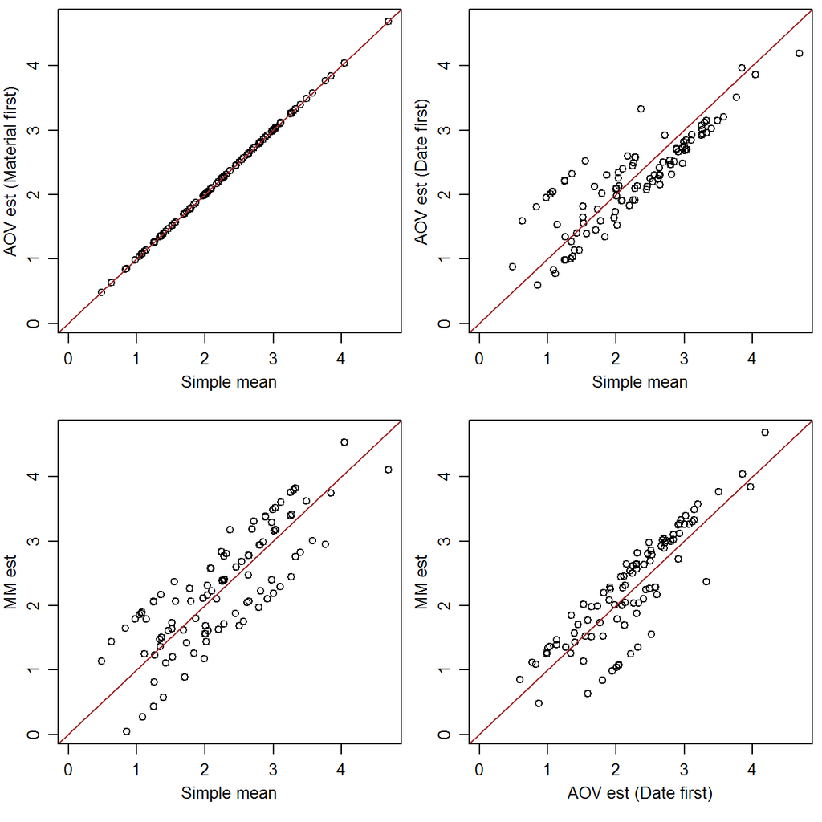

```r
ttMn <- cbind(ests, simpleMn=tapply(sqrt(TaAgg$lesArea), TaAgg$Material, mean, na.rm=TRUE),
              aovEst=model.tables(selnAOV, type='means')$tables$Material,
              aov1Est=model.tables(selnAOV1, type='means')$tables$Material)
par(mfrow=c(2,2), mgp=c(2, 0.8, 0), mar=c(4,3,0.5,0.5))
axLim <- range(ttMn[,c('simpleMn','aovEst','aov1Est','Estimate')])
plot(ttMn[,'simpleMn'], ttMn[,'aovEst'], xlab='Simple mean', xlim=axLim, ylim=axLim,
     ylab='AOV est (Material first)', panel.last=abline(0, 1, col='brown'))
plot(ttMn[,'simpleMn'], ttMn[,'aov1Est'], xlab='Simple mean', xlim=axLim, ylim=axLim,
     ylab='AOV est (Date first)', panel.last=abline(0, 1, col='brown'))
plot(ttMn[,'simpleMn'], ttMn[,'Estimate'], xlab='Simple mean', xlim=axLim, ylim=axLim,
     ylab='MM est', panel.last=abline(0, 1, col='brown'))
plot(ttMn[,'aov1Est'], ttMn[,'aovEst'], xlab='AOV est (Date first)', xlim=axLim, ylim=axLim,
     ylab='MM est', panel.last=abline(0, 1, col='brown'))
```

Notes on the code:

- Means will all be in the same order so we can simply `cbind` them together
- The use of `range` and `xlim` and `ylim` are introduced
- In the `plot` function call we have used `panel.last` which allows us to call a particular function to be executed after the points have been plotted (`panel.first` executes the function before the plotting of the points). Here `abline` is called, which as formulated draws the line of equality in brown
- It can be seen that both the AOV fitting dates first, and the mixed model adjust for dates. When the experiment is unbalanced (as this one is), mixed models are generally preferred.

## Dot plot of the estimates

One could fit the families separately, but I have decided to simply draw a dotplot - colour-coded by family.

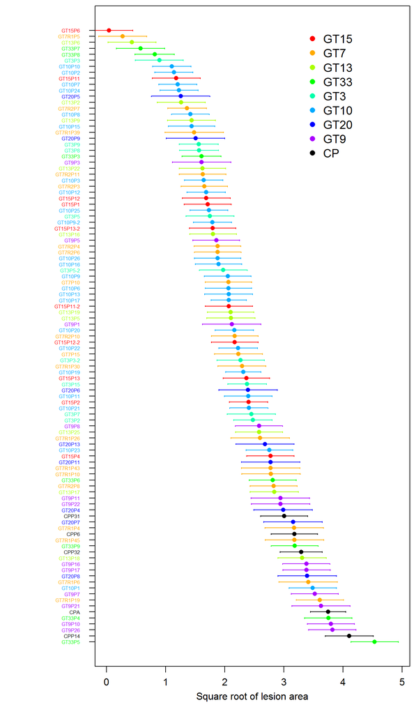

```r
rownames(estsOrd) <- gsub('Material', '', rownames(estsOrd))
# Omit 3 and6 since I don't know what they are
dpData <- as.data.frame(estsOrd[!(rownames(estsOrd) %in% c(3,6)),])
dpData$Family <- substring(rownames(dpData), 1, 4)
dpData[substring(dpData$Family, 1, 1)=='C','Family'] <-
  substring(dpData[substring(dpData$Family, 1, 1)=='C','Family'], 1, 3)
dpData[substring(dpData$Family, 1, 1)=='G' &
         substring(dpData$Family, 4) %in% c('P','R'),'Family'] <-
  substring(dpData[substring(dpData$Family, 1, 1)=='G' &
                     substring(dpData$Family, 4) %in% c('P','R'),'Family'], 1, 3)
dpData$Family <- factor(dpData$Family, unique(dpData$Family))
ttCols <- rainbow(nlevels(dpData$Family)-1)
dpData[substring(dpData$Family, 1, 1)=='G', 'famCols'] <-
  ttCols[as.numeric(dpData[substring(dpData$Family, 1, 1)=='G', 'Family'])]
dpData[dpData$Family %in% c('CPA','CPP'), 'famCols'] <- 'black'
dpData <- dpData[order(-dpData$Estimate),] # reverse order
nR <- nrow(dpData)
par(mfrow=c(1,1), mgp=c(2,0.8,0), mar=c(4,8,0.5,0.5))
plot(dpData$Estimate, 1:nR, xlim=c(0, max(dpData$Estimate+dpData$`Std. Error`)),
     col=dpData$famCols, pch=16, yaxt='n', xlab='Square root of lesion area', ylab='')
arrows(dpData$Estimate+dpData$`Std. Error`, 1:nR,
       dpData$Estimate-dpData$`Std. Error`, 1:nR,
       angle=90, length=0.01, code=3, col=dpData$famCols)
axis(2, 1:nR, rep('', nR))
text(-0.45, 1:nR, rownames(dpData), col=dpData$famCols, adj=1, cex=0.5, xpd=TRUE)
legend(3.3, nR+1, c(levels(dpData$Family)[-(9:10)],'CP'), col=c(ttCols[-9], 'black'),
       pch=16, cex=1.2, bty='n')
```

Notes on the code:

- This code introduces several new functions:
  - `rownames`
  - `nrow`
  - `unique` to return only the unique values in the order in which they appear
  - `gsub` to substitute a target string with a replacement string in the vector of characters. In this case it replaces ‘material’ with the empty string ’’ (i.e., it removes ’material’from the row names)
  - `text`to place text on a plot
  - `arrows` to draw arrows. By making the angle of the arrow point 90, we can draw standard error bars
  - `rainbow` to create colours in the spectrum. One can also use `terrain.colors`, `topo.colors` and `heat.colors`
- It also introduces the `%in%` operator which returns TRUE if an element of the vector on the left hand side is present in the vector on the right, and FALSE otherwise
- To undersand the code, it is best to step through it line by line, making sure that each line is understood. It can also be useful to look at the help files on the functions. If you still can’t follow, please send me an email.